# ADR Survey Analysis

2020-07-03

### Document History

Original Publish Date: 03 July, 2020

Updated on: 13 April, 2021

In this post we analyse the performance of dynast MPs in their constituency by using a pan India survey conducted by Daksh and ADR on governance issues for the year 2013-14. The survey was conducted across 535 constituencies and it witnessed participation of 2.5 lakh+ voters.

Apart from few questions survey was trying to measure two things. What are the constituents most pressing concerns and how well their representative perform in those areas. They are ranked from 1 to 3 where one means bad and three means good. Apart from that, they have also created a composite index of these two, which is rated out of 10.

The data we accessed has around 480 unique constituencies and we have been able to match ~405 constituencies from the survey data to our dynasty data. For all India analysis we are using the 2009 GE file where we have collected information regarding the dynast status from secondary resources. However, for the UP analysis we are using our own primary data.

# All India

## Over all rating

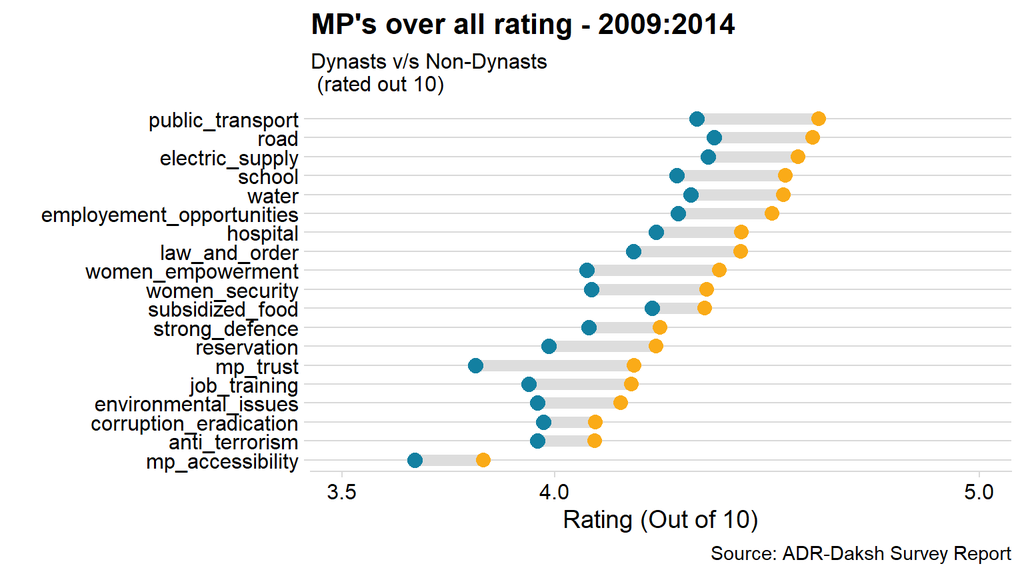

## Important issues to the constituents

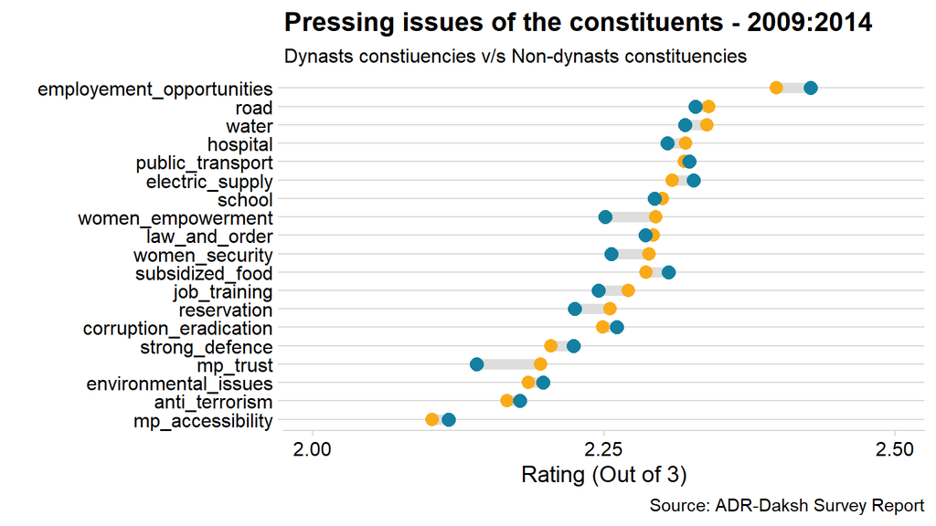

## MP’s performance

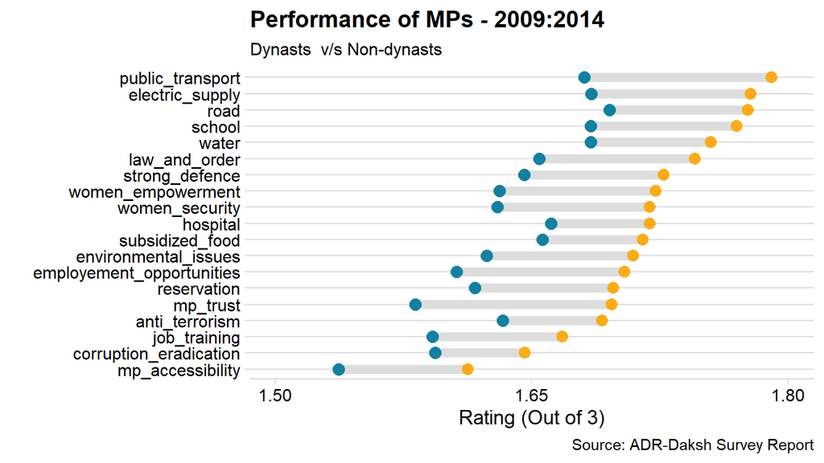

# Other questions

## Why do you vote for a candidate?

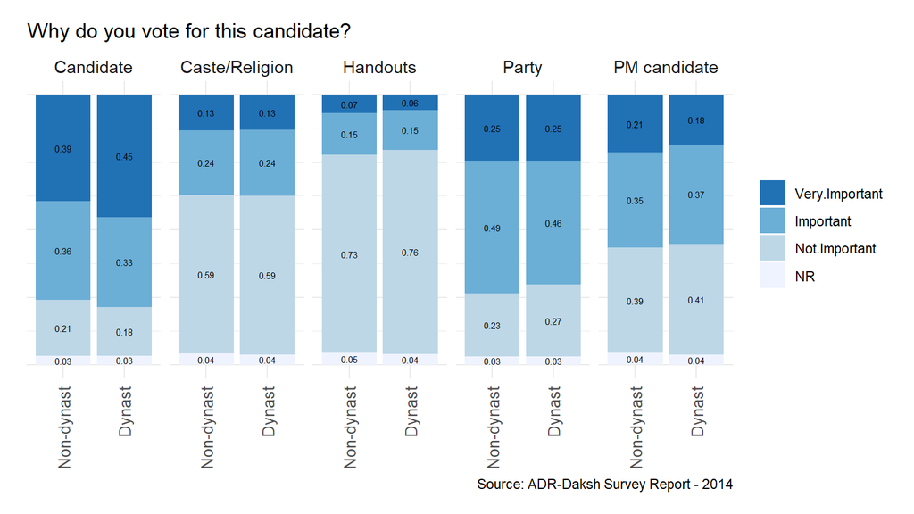

## Why do you vote for a criminal candidate?

Why do you vote for a criminal candidate?

| question | dynast | NR | No | Yes |
| --- | --- | --- | --- | --- |
| Candidate is of similar caste or religion | 0 | 0.04 | 0.60 | 0.36 |
| Candidate is of similar caste or religion | 1 | 0.04 | 0.61 | 0.35 |
| Candidate is powerful | 0 | 0.04 | 0.57 | 0.39 |
| Candidate is powerful | 1 | 0.03 | 0.61 | 0.36 |
| Candidate otherwise does good work | 0 | 0.04 | 0.30 | 0.66 |
| Candidate otherwise does good work | 1 | 0.04 | 0.32 | 0.64 |
| Cases against him are not serious | 0 | 0.04 | 0.53 | 0.43 |
| Cases against him are not serious | 1 | 0.04 | 0.55 | 0.40 |
| Candidate has spent generously in elections | 0 | 0.04 | 0.57 | 0.39 |
| Candidate has spent generously in elections | 1 | 0.03 | 0.59 | 0.38 |
| Voters don’t know about the criminal record | 0 | 0.04 | 0.54 | 0.42 |
| Voters don’t know about the criminal record | 1 | 0.04 | 0.55 | 0.41 |

## Miscellanious questions

miscellaneous questions

| question | dynast | NR | No | Yes |
| --- | --- | --- | --- | --- |
| Did you hear abut candidate distributing handouts? | 0 | 0.02 | 0.66 | 0.32 |
| Did you hear abut candidate distributing handouts? | 1 | 0.01 | 0.65 | 0.34 |
| Did you kow that the distribution of handouts are illegal? | 0 | 0.02 | 0.30 | 0.68 |
| Did you kow that the distribution of handouts are illegal? | 1 | 0.02 | 0.28 | 0.71 |
| Do you know that you can get information on the criminal record of the candidates? | 0 | 0.02 | 0.64 | 0.34 |
| Do you know that you can get information on the criminal record of the candidates? | 1 | 0.02 | 0.65 | 0.33 |
| Do you think people should vote for a candidates with a criminal record? | 0 | 0.43 | 0.45 | 0.13 |
| Do you think people should vote for a candidates with a criminal record? | 1 | 0.50 | 0.40 | 0.10 |

# UP

## Over all rating

[figure not shown]

## Important issues to the constituents

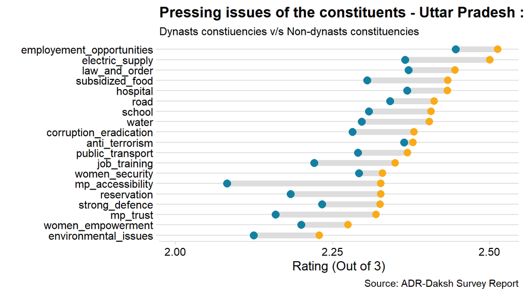

## MP’s performance

[figure not shown]